# Life Expectancy project

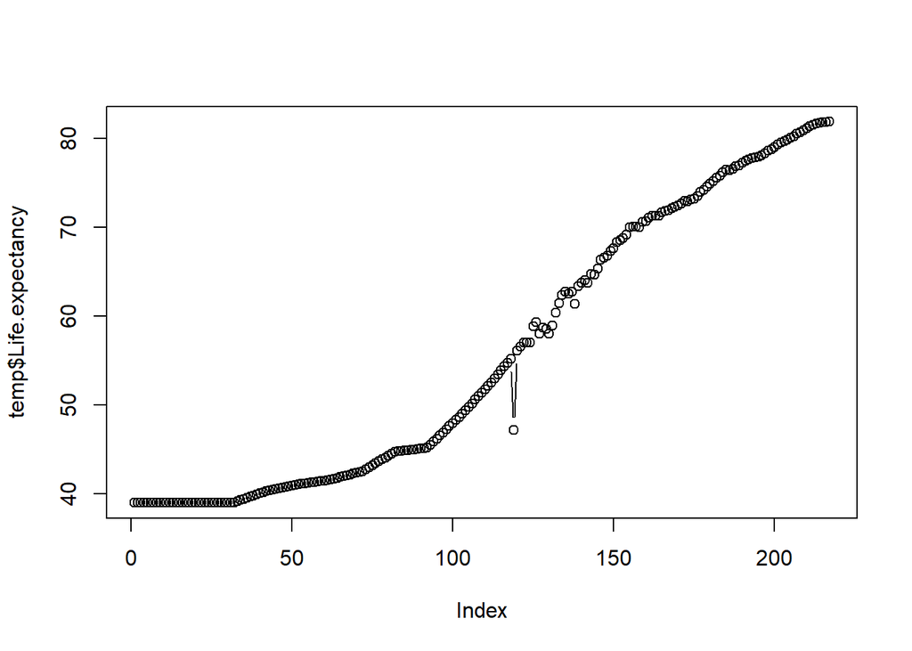

```r
plot(temp$Life.expectancy, type = 'b')
```

Pie chart

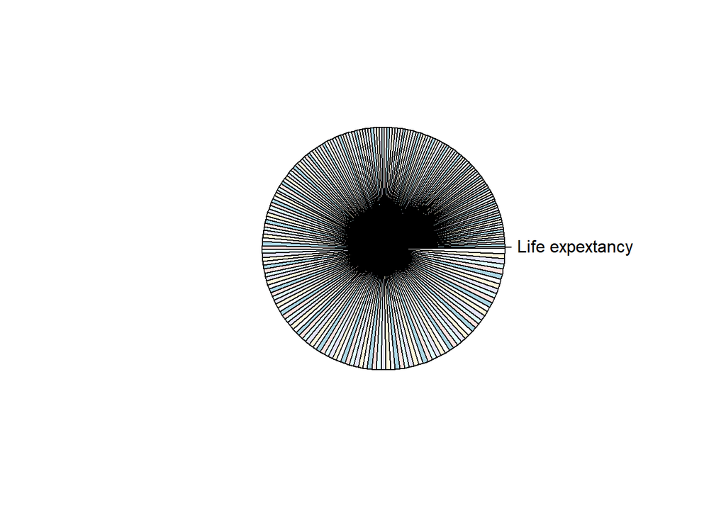

```r
pie(temp$Life.expectancy, labels = 'Life expextancy')
```

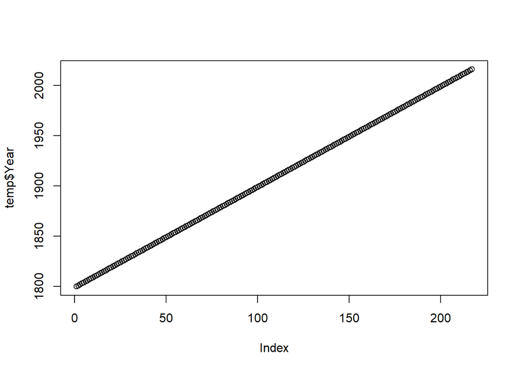

```r
plot(temp$Year, type = 'b')
```

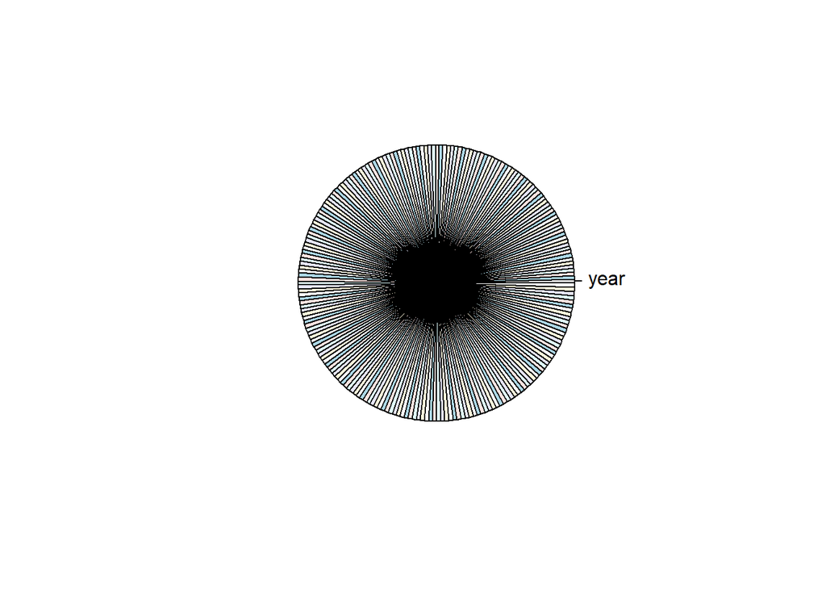

```r
pie(temp$Year, labels = 'year')
```

Cleveland Dot Charts

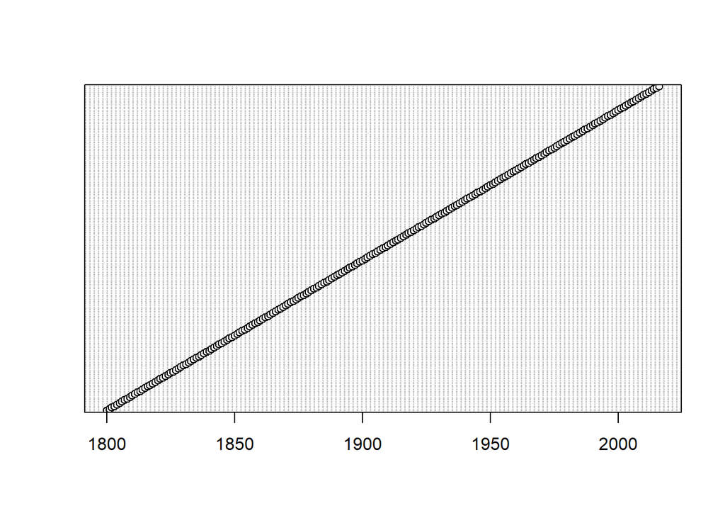

```r
dotchart(temp$Year)
```

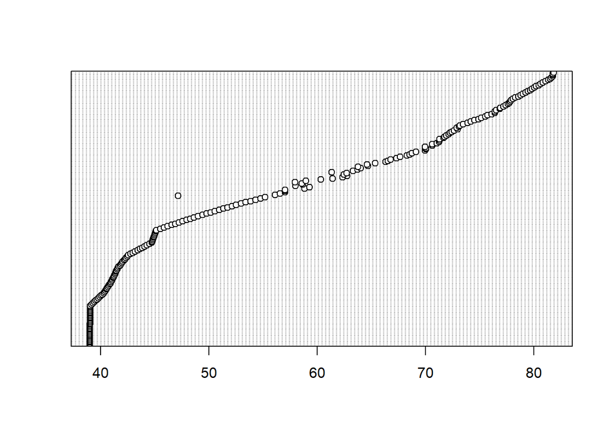

```r
dotchart(temp$Life.expectancy)
```

Bar plot

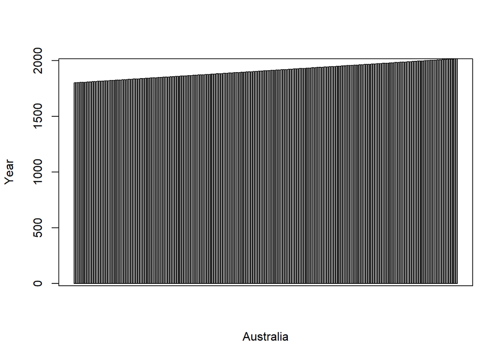

```r
barplot(temp$Year)
title(xlab = 'Australia', ylab = 'Year')
box()
```

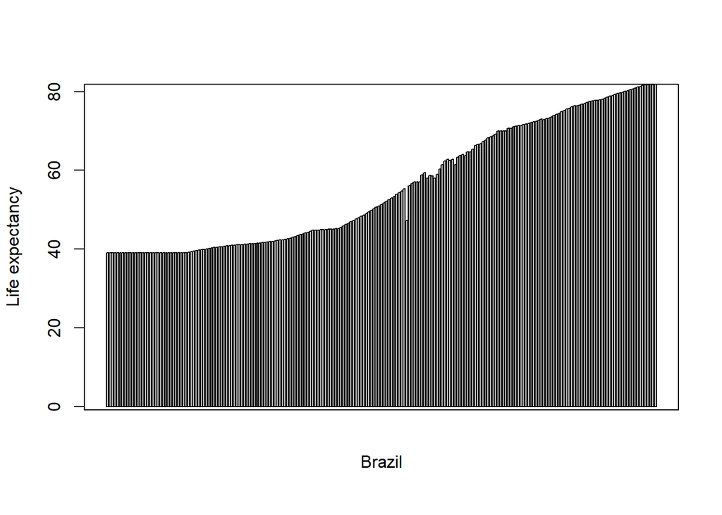

```r
barplot(temp$Life.expectancy)
title(xlab = 'Brazil
      ', ylab = 'Life expectancy')
box()
```

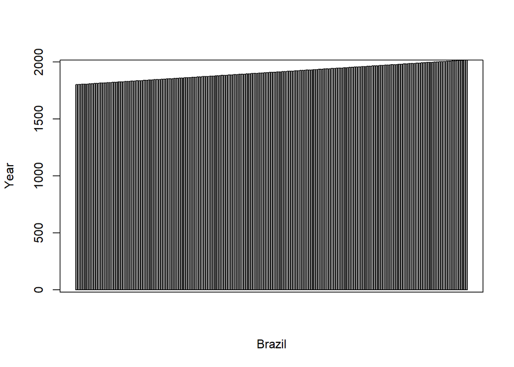

```r
barplot(temp$Year)
title(xlab = 'Brazil', ylab = 'Year')
box()
```

to get the column’s diff level(type) counts

```r
table(df$Entity)
```

```
##
##      Australia         Brazil         Canada          China         France
##            215            217            217            217            217
##        Germany          India          Italy          Japan         Mexico
##            217            217            217            217            217
##         Russia          Spain    Switzerland United Kingdom  United States
##            217            217            217            217            217
```

[figure not shown]

```r
barplot(temp$Life.expectancy, horiz = T)
title(xlab = 'Australia', ylab = 'Life expectancy')
box()
```

[figure not shown]

```r
barplot(temp$Life.expectancy, horiz = T)
title(xlab = 'Canada', ylab = 'Life expectancy')
box()
```

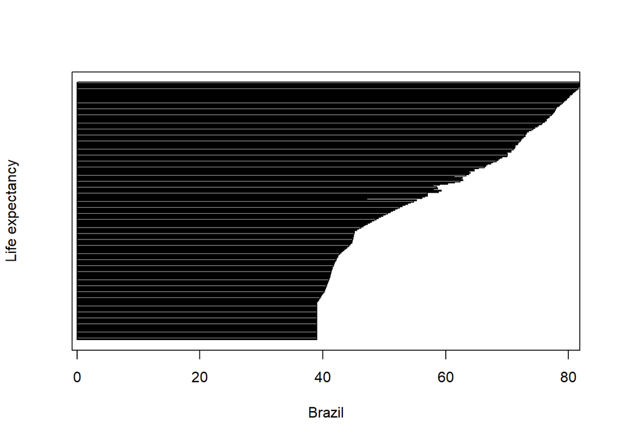

```r
barplot(temp$Life.expectancy, horiz = T)
title(xlab = 'Brazil', ylab = 'Life expectancy')
box()
```

the analysis of variance

```r
temp.aov = na.omit(aov(temp$Life.expectancy ~ temp$Year, data = temp))
temp.aov
```

```
## Call:
##    aov(formula = temp$Life.expectancy ~ temp$Year, data = temp)
##
## Terms:
##                 temp$Year Residuals
## Sum of Squares   47561.91   2897.08
## Deg. of Freedom         1       215
##
## Residual standard error: 3.670804
## Estimated effects may be unbalanced
```

```r
temp.aov = na.omit(aov(temp$Year ~ temp$Life.expectancy, data = temp))
temp.aov
```

```
## Call:
##    aov(formula = temp$Year ~ temp$Life.expectancy, data = temp)
##
## Terms:
##                 temp$Life.expectancy Residuals
## Sum of Squares                802619     48889
## Deg. of Freedom                    1       215
##
## Residual standard error: 15.07948
## Estimated effects may be unbalanced
```

To see the classic ANOVA table

```r
summary(temp.aov)
```

```
##                       Df Sum Sq Mean Sq F value Pr(>F)
## temp$Life.expectancy   1 802619  802619    3530 <2e-16 ***
## Residuals            215  48889     227
## ---
## Signif. codes:  0 '***' 0.001 '**' 0.01 '*' 0.05 '.' 0.1 ' ' 1
```

```r
factor(df$Entity)
```

[output not shown]

[output cut: 800 more lines]

creating new testCol

```r
testCol = c(rep(df$Year - df$Life.expectancy, length(df)))
head(testCol)
```

```
## [1] 1767.95 1768.95 1769.95 1770.95 1771.95 1772.95
```

```r
testRow = c('Australia', 1803, 34.05)
testRow
```

```
## [1] "Australia" "1803"      "34.05"
```

```r
testCol = c(rep(df$Life.expectancy - df$Year, length(df)))
head(testCol)
```

```
## [1] -1767.95 -1768.95 -1769.95 -1770.95 -1771.95 -1772.95
```

```r
testRow = c('Spain', 1919, 41.12)
testRow
```

```
## [1] "Spain" "1919"  "41.12"
```

Adding Rows or Columns

```r
test = data.frame(df, testCol)
head(test)
```

```
##      Entity Year Life.expectancy  testCol
## 1 Australia 1802           34.05 -1767.95
## 2 Australia 1803           34.05 -1768.95
## 3 Australia 1804           34.05 -1769.95
## 4 Australia 1805           34.05 -1770.95
## 5 Australia 1806           34.05 -1771.95
## 6 Australia 1807           34.05 -1772.95
```

```r
test = df
test['testRow',] = testRow
tail(test)
```

```
##                Entity Year Life.expectancy
## 3249    United States 2012       78.940002
## 3250    United States 2013       78.959999
## 3251    United States 2014       78.940002
## 3252    United States 2015       78.870003
## 3253    United States 2016       78.860001
## testRow         Spain 1919           41.12
```

```r
test = df
test["Test",] = NA
tail(test)
```

```
##             Entity Year Life.expectancy
## 3249 United States 2012           78.94
## 3250 United States 2013           78.96
## 3251 United States 2014           78.94
## 3252 United States 2015           78.87
## 3253 United States 2016           78.86
## Test          <NA>   NA              NA
```

Column Indexes

```r
col(temp, as.factor = F)
```

```
##        [,1] [,2] [,3]
##   [1,]    1    2    3
##   [2,]    1    2    3
##   [3,]    1    2    3
##   [4,]    1    2    3
##   [5,]    1    2    3
##   [6,]    1    2    3
##   [7,]    1    2    3
##   [8,]    1    2    3
##   [9,]    1    2    3
##  [10,]    1    2    3
##  [11,]    1    2    3
##  [12,]    1    2    3
##  [13,]    1    2    3
##  [14,]    1    2    3
```

[output cut: 203 more lines]

Extracting two(2) columns from df

```r
x = df[ , 1:2]
head(x)
```

```
##      Entity Year
## 1 Australia 1802
## 2 Australia 1803
## 3 Australia 1804
## 4 Australia 1805
## 5 Australia 1806
## 6 Australia 1807
```

```r
x = df[ , 2:3]
head(x)
```

```
##   Year Life.expectancy
## 1 1802           34.05
## 2 1803           34.05
## 3 1804           34.05
## 4 1805           34.05
## 5 1806           34.05
## 6 1807           34.05
```

Simple Column and Row Summaries

```r
colMeans(x)
```

```
##            Year Life.expectancy
##      1908.06609        48.68038
```

```r
rowMeans(x)
```

```
##    [1]  918.0250  918.5250  919.0250  919.5250  920.0250  920.5250  921.0250
##    [8]  921.5250  922.0250  922.5250  923.0250  923.5250  924.0250  924.5250
##   [15]  925.0250  925.5250  926.0250  926.5250  927.0250  927.5250  928.0250
##   [22]  928.5250  929.0250  929.5250  930.0250  930.5250  931.0250  931.5250
##   [29]  932.0250  932.5250  933.0250  933.5250  934.0250  934.5250  935.0250
##   [36]  935.5250  936.0250  936.5250  937.0250  937.5250  938.0250  938.5250
##   [43]  939.0250  939.5250  940.0250  940.5250  941.0250  941.5250  942.0250
##   [50]  942.5250  943.0250  943.5250  944.0250  944.5250  945.0250  945.5250
##   [57]  946.0250  946.5250  947.0250  947.5250  948.0250  948.5250  949.0250
##   [64]  949.5250  950.0250  950.5250  951.0250  951.5250  952.0250  952.7896
##   [71]  953.5542  954.3188  955.0834  955.8480  956.6126  957.3773  958.1419
##   [78]  958.9065  959.6711  960.4357  961.2003  961.9649  962.7295  963.4941
##   [85]  964.2587  965.0233  965.7879  966.5525  967.3172  968.0818  968.8464
##   [92]  969.6110  970.3756  971.1402  971.9048  972.6694  973.4340  974.1986
##   [99]  974.9632  975.7278  976.4925  977.2571  978.0217  978.7863  979.5509
```

[output cut: 450 more lines]

```r
colSums(x)
```

```
##            Year Life.expectancy
##       6206939.0        158357.3
```

```r
rowSums(x)
```

```
##    [1] 1836.050 1837.050 1838.050 1839.050 1840.050 1841.050 1842.050 1843.050
##    [9] 1844.050 1845.050 1846.050 1847.050 1848.050 1849.050 1850.050 1851.050
##   [17] 1852.050 1853.050 1854.050 1855.050 1856.050 1857.050 1858.050 1859.050
##   [25] 1860.050 1861.050 1862.050 1863.050 1864.050 1865.050 1866.050 1867.050
##   [33] 1868.050 1869.050 1870.050 1871.050 1872.050 1873.050 1874.050 1875.050
##   [41] 1876.050 1877.050 1878.050 1879.050 1880.050 1881.050 1882.050 1883.050
##   [49] 1884.050 1885.050 1886.050 1887.050 1888.050 1889.050 1890.050 1891.050
##   [57] 1892.050 1893.050 1894.050 1895.050 1896.050 1897.050 1898.050 1899.050
##   [65] 1900.050 1901.050 1902.050 1903.050 1904.050 1905.579 1907.108 1908.638
##   [73] 1910.167 1911.696 1913.225 1914.755 1916.284 1917.813 1919.342 1920.871
##   [81] 1922.401 1923.930 1925.459 1926.988 1928.517 1930.047 1931.576 1933.105
##   [89] 1934.634 1936.164 1937.693 1939.222 1940.751 1942.280 1943.810 1945.339
##   [97] 1946.868 1948.397 1949.926 1951.456 1952.985 1954.514 1956.043 1957.573
##  [105] 1959.102 1960.631 1962.160 1963.689 1965.219 1966.748 1968.277 1969.806
##  [113] 1971.335 1972.865 1974.394 1975.923 1972.802 1978.982 1980.511 1982.040
```

[output cut: 392 more lines]

to apply a function over all the rows or columns of a data frame

```r
apply(df[ , 1:3], 2, mean)
```

```
##          Entity            Year Life.expectancy
##              NA              NA              NA
```

```r
apply(df[ , 1:2], 1, mean)
```

[output not shown]

[output cut: 9703 more lines]

[output not shown]

[output not shown]

[output cut: 121 more lines]

```r
apply(df[ , 1:3], 2, median)
```

```
##          Entity            Year Life.expectancy
##         "Italy"          "1908"     "41.880001"
```

```r
apply(df[ , 2:3], 2, median)
```

```
##            Year Life.expectancy
##         1908.00           41.88
```

```r
apply(df[ , 1:3], 2, var)
```

```
##          Entity            Year Life.expectancy
##              NA       3920.5082        322.7653
```

```r
apply(df[ , 1:3], 2, var)
```

```
##          Entity            Year Life.expectancy
##              NA       3920.5082        322.7653
```

Using tapply() to Summarize Using a Grouping Variable

```r
tapply(df$Year, df$Entity, FUN = mean)
```

```
##      Australia         Brazil         Canada          China         France
##           1909           1908           1908           1908           1908
##        Germany          India          Italy          Japan         Mexico
##           1908           1908           1908           1908           1908
##         Russia          Spain    Switzerland United Kingdom  United States
##           1908           1908           1908           1908           1908
```

```r
tapply(df$Life.expectancy, df$Entity, FUN = mean)
```

```
##      Australia         Brazil         Canada          China         France
##       54.29000       42.39229       55.77853       41.45284       53.69172
##        Germany          India          Italy          Japan         Mexico
##       52.88094       34.29258       49.22636       50.34571       40.83563
##         Russia          Spain    Switzerland United Kingdom  United States
##       41.99298       47.58878       55.24604       55.59195       54.65106
```

```r
aggregate(df[ , 1:3], by = list(df$Entity), FUN = mean)
```

[output not shown]

```
##           Group.1 Entity Year Life.expectancy
## 1       Australia     NA 1909        54.29000
## 2          Brazil     NA 1908        42.39229
## 3          Canada     NA 1908        55.77853
## 4           China     NA 1908        41.45284
## 5          France     NA 1908        53.69172
## 6         Germany     NA 1908        52.88094
## 7           India     NA 1908        34.29258
## 8           Italy     NA 1908        49.22636
## 9           Japan     NA 1908        50.34571
## 10         Mexico     NA 1908        40.83563
## 11         Russia     NA 1908        41.99298
## 12          Spain     NA 1908        47.58878
## 13    Switzerland     NA 1908        55.24604
## 14 United Kingdom     NA 1908        55.59195
## 15  United States     NA 1908        54.65106
```

uding cbind()

```r
aggregate(cbind(df$Life.expectancy, df$Year), data = df, by = list(df$Entity), FUN = mean)
```

```
##           Group.1       V1   V2
## 1       Australia 54.29000 1909
## 2          Brazil 42.39229 1908
## 3          Canada 55.77853 1908
## 4           China 41.45284 1908
## 5          France 53.69172 1908
## 6         Germany 52.88094 1908
## 7           India 34.29258 1908
## 8           Italy 49.22636 1908
## 9           Japan 50.34571 1908
## 10         Mexico 40.83563 1908
## 11         Russia 41.99298 1908
## 12          Spain 47.58878 1908
## 13    Switzerland 55.24604 1908
## 14 United Kingdom 55.59195 1908
## 15  United States 54.65106 1908
```